# Bellabeat Case Study in R

Tzu Yu Chiu

2023-10-04

### Introduction

#### About the company

Bellabeat, a technology company with a strong focus on health, was co-founded by Urška Sršen and Sando Mur. Leveraging her artistic background, Sršen played a pivotal role in crafting elegantly designed tech solutions that serve as a source of information and inspiration for women across the globe. By gathering data related to activity, sleep, stress, and reproductive health, Bellabeat has effectively equipped women with valuable insights into their personal well-being and lifestyle patterns.

#### Data

This dataset generated by respondents to a distributed survey via Amazon Mechanical Turk between 04.12.2016-05.12.2016.It can be found on [Kaggle](https://www.kaggle.com/datasets/arashnic/fitbit).

### Research Questions

The primary objective of this case study is to conduct a comprehensive data analysis, with the overarching goal of identifying promising growth opportunities and formulating precise recommendations. These recommendations are specifically designed to enhance Bellabeat’s marketing strategy, and they are grounded in the latest trends pertaining to the utilization of smart devices.

1. What are some trends in smart device usage?
2. How could these trends apply to Bellabeat customers?
3. How could these trends help influence Bellabeat marketing strategy?

### Loading packages

```r
library(tidyverse)
```

```r
library(lubridate)
library(ggplot2)
library(dplyr)
```

### Importing datasets

```r
daily_activity <- read_csv("/Users/tzuyuchiu/Desktop/Google Data Analystic/case_study/Bellabeat/dataset/fitabase_data/dailyActivity_merged.csv")
daily_sleep <- read_csv("/Users/tzuyuchiu/Desktop/Google Data Analystic/case_study/Bellabeat/dataset/fitabase_data/sleepDay_merged.csv")
weight_log <-read_csv("/Users/tzuyuchiu/Desktop/Google Data Analystic/case_study/Bellabeat/dataset/fitabase_data/weightLogInfo_merged.csv")
```

### Exploring datasets

```r
# Check how many users in each datasets
n_distinct(daily_activity$Id)
```

```
## [1] 33
```

```r
n_distinct(daily_sleep$Id)
```

```
## [1] 24
```

```r
n_distinct(weight_log$Id)
```

```
## [1] 8
```

There is 33 users in the daily activity data sets, 24 in the daily sleep and only 8 in the weight_log data set. Given that the data comprises only 8 users during the short time period, it is insufficient to draw any meaningful recommendations or conclusions.

```r
# high-level overview of dataset
head(daily_activity)
```

```
## # A tibble: 6 × 15
##           Id ActivityDate TotalSteps TotalDistance TrackerDistance
##        <dbl> <chr>             <dbl>         <dbl>           <dbl>
## 1 1503960366 4/12/2016         13162          8.5             8.5
## 2 1503960366 4/13/2016         10735          6.97            6.97
## 3 1503960366 4/14/2016         10460          6.74            6.74
## 4 1503960366 4/15/2016          9762          6.28            6.28
## 5 1503960366 4/16/2016         12669          8.16            8.16
## 6 1503960366 4/17/2016          9705          6.48            6.48
## # ℹ 10 more variables: LoggedActivitiesDistance <dbl>,
## #   VeryActiveDistance <dbl>, ModeratelyActiveDistance <dbl>,
## #   LightActiveDistance <dbl>, SedentaryActiveDistance <dbl>,
## #   VeryActiveMinutes <dbl>, FairlyActiveMinutes <dbl>,
## #   LightlyActiveMinutes <dbl>, SedentaryMinutes <dbl>, Calories <dbl>
```

```r
head(daily_sleep)
```

```
## # A tibble: 6 × 5
##           Id SleepDay        TotalSleepRecords TotalMinutesAsleep TotalTimeInBed
##        <dbl> <chr>                       <dbl>              <dbl>          <dbl>
## 1 1503960366 4/12/2016 12:0…                 1                327            346
## 2 1503960366 4/13/2016 12:0…                 2                384            407
## 3 1503960366 4/15/2016 12:0…                 1                412            442
## 4 1503960366 4/16/2016 12:0…                 2                340            367
## 5 1503960366 4/17/2016 12:0…                 1                700            712
## 6 1503960366 4/19/2016 12:0…                 1                304            320
```

```r
head(weight_log)
```

```
## # A tibble: 6 × 8
##           Id Date       WeightKg WeightPounds   Fat   BMI IsManualReport   LogId
##        <dbl> <chr>         <dbl>        <dbl> <dbl> <dbl> <lgl>            <dbl>
## 1 1503960366 5/2/2016 …     52.6         116.    22  22.6 TRUE           1.46e12
## 2 1503960366 5/3/2016 …     52.6         116.    NA  22.6 TRUE           1.46e12
## 3 1927972279 4/13/2016…    134.          294.    NA  47.5 FALSE          1.46e12
## 4 2873212765 4/21/2016…     56.7         125.    NA  21.5 TRUE           1.46e12
## 5 2873212765 5/12/2016…     57.3         126.    NA  21.7 TRUE           1.46e12
## 6 4319703577 4/17/2016…     72.4         160.    25  27.5 TRUE           1.46e12
```

We can see that the format of date columns for each datasets are not aligned and the datatype are strings instead of date

```r
# Convert datatype from string to date
# activity
daily_activity$ActivityDate <- mdy(daily_activity$ActivityDate)
head(daily_activity)
```

```
## # A tibble: 6 × 15
##           Id ActivityDate TotalSteps TotalDistance TrackerDistance
##        <dbl> <date>            <dbl>         <dbl>           <dbl>
## 1 1503960366 2016-04-12        13162          8.5             8.5
## 2 1503960366 2016-04-13        10735          6.97            6.97
## 3 1503960366 2016-04-14        10460          6.74            6.74
## 4 1503960366 2016-04-15         9762          6.28            6.28
## 5 1503960366 2016-04-16        12669          8.16            8.16
## 6 1503960366 2016-04-17         9705          6.48            6.48
## # ℹ 10 more variables: LoggedActivitiesDistance <dbl>,
## #   VeryActiveDistance <dbl>, ModeratelyActiveDistance <dbl>,
## #   LightActiveDistance <dbl>, SedentaryActiveDistance <dbl>,
## #   VeryActiveMinutes <dbl>, FairlyActiveMinutes <dbl>,
## #   LightlyActiveMinutes <dbl>, SedentaryMinutes <dbl>, Calories <dbl>
```

```r
# sleep
daily_sleep_split<- separate(daily_sleep, SleepDay, into=c('ActivityDate','time', 'am_pm'), sep=" ", remove=TRUE)
daily_sleep_split$ActivityDate <- mdy(daily_sleep_split$ActivityDate)
head(daily_sleep_split)
```

```
## # A tibble: 6 × 7
##           Id ActivityDate time     am_pm TotalSleepRecords TotalMinutesAsleep
##        <dbl> <date>       <chr>    <chr>             <dbl>              <dbl>
## 1 1503960366 2016-04-12   12:00:00 AM                    1                327
## 2 1503960366 2016-04-13   12:00:00 AM                    2                384
## 3 1503960366 2016-04-15   12:00:00 AM                    1                412
## 4 1503960366 2016-04-16   12:00:00 AM                    2                340
## 5 1503960366 2016-04-17   12:00:00 AM                    1                700
## 6 1503960366 2016-04-19   12:00:00 AM                    1                304
## # ℹ 1 more variable: TotalTimeInBed <dbl>
```

```r
# weight_log
weight_log_split<- separate(weight_log, Date, into=c('ActivityDate','time', 'am_pm'), sep=" ", remove=TRUE)
weight_log_split$ActivityDate <- mdy(weight_log_split$ActivityDate)
head(weight_log_split)
```

```
## # A tibble: 6 × 10
##           Id ActivityDate time     am_pm WeightKg WeightPounds   Fat   BMI
##        <dbl> <date>       <chr>    <chr>    <dbl>        <dbl> <dbl> <dbl>
## 1 1503960366 2016-05-02   11:59:59 PM        52.6         116.    22  22.6
## 2 1503960366 2016-05-03   11:59:59 PM        52.6         116.    NA  22.6
## 3 1927972279 2016-04-13   1:08:52  AM       134.          294.    NA  47.5
## 4 2873212765 2016-04-21   11:59:59 PM        56.7         125.    NA  21.5
## 5 2873212765 2016-05-12   11:59:59 PM        57.3         126.    NA  21.7
## 6 4319703577 2016-04-17   11:59:59 PM        72.4         160.    25  27.5
## # ℹ 2 more variables: IsManualReport <lgl>, LogId <dbl>
```

After fixed date columns in each dataset, let’s check the statistic summary

```r
# Explore and summarize data
daily_activity %>%
  dplyr::select(ActivityDate,TotalSteps,TotalDistance,Calories,VeryActiveMinutes,FairlyActiveMinutes,LightlyActiveMinutes,SedentaryMinutes) %>%
  summary()
```

```
##   ActivityDate          TotalSteps    TotalDistance       Calories
##  Min.   :2016-04-12   Min.   :    0   Min.   : 0.000   Min.   :   0
##  1st Qu.:2016-04-19   1st Qu.: 3790   1st Qu.: 2.620   1st Qu.:1828
##  Median :2016-04-26   Median : 7406   Median : 5.245   Median :2134
##  Mean   :2016-04-26   Mean   : 7638   Mean   : 5.490   Mean   :2304
##  3rd Qu.:2016-05-04   3rd Qu.:10727   3rd Qu.: 7.713   3rd Qu.:2793
##  Max.   :2016-05-12   Max.   :36019   Max.   :28.030   Max.   :4900
##  VeryActiveMinutes FairlyActiveMinutes LightlyActiveMinutes SedentaryMinutes
##  Min.   :  0.00    Min.   :  0.00      Min.   :  0.0        Min.   :   0.0
##  1st Qu.:  0.00    1st Qu.:  0.00      1st Qu.:127.0        1st Qu.: 729.8
##  Median :  4.00    Median :  6.00      Median :199.0        Median :1057.5
##  Mean   : 21.16    Mean   : 13.56      Mean   :192.8        Mean   : 991.2
##  3rd Qu.: 32.00    3rd Qu.: 19.00      3rd Qu.:264.0        3rd Qu.:1229.5
##  Max.   :210.00    Max.   :143.00      Max.   :518.0        Max.   :1440.0
```

```r
daily_sleep_split %>%
  dplyr::select(ActivityDate,TotalMinutesAsleep,TotalTimeInBed) %>%
  summary()
```

```
##   ActivityDate        TotalMinutesAsleep TotalTimeInBed
##  Min.   :2016-04-12   Min.   : 58.0      Min.   : 61.0
##  1st Qu.:2016-04-19   1st Qu.:361.0      1st Qu.:403.0
##  Median :2016-04-27   Median :433.0      Median :463.0
##  Mean   :2016-04-26   Mean   :419.5      Mean   :458.6
##  3rd Qu.:2016-05-04   3rd Qu.:490.0      3rd Qu.:526.0
##  Max.   :2016-05-12   Max.   :796.0      Max.   :961.0
```

```r
weight_log_split %>%
  dplyr::select(ActivityDate,WeightKg,BMI) %>%
  summary()
```

```
##   ActivityDate           WeightKg           BMI
##  Min.   :2016-04-12   Min.   : 52.60   Min.   :21.45
##  1st Qu.:2016-04-19   1st Qu.: 61.40   1st Qu.:23.96
##  Median :2016-04-27   Median : 62.50   Median :24.39
##  Mean   :2016-04-26   Mean   : 72.04   Mean   :25.19
##  3rd Qu.:2016-05-04   3rd Qu.: 85.05   3rd Qu.:25.56
##  Max.   :2016-05-12   Max.   :133.50   Max.   :47.54
```

The statistical summary reveals a noteworthy concern regarding Sedentary Minutes, where the average is very high at 991 minutes. It is imperative that we conduct an in-depth analysis of this particular metric.

### Merging data

Before going the analysis part, I want to merge two datasets: Activity and Sleep by using Id and ActivityDate columns

```r
# Merge Daily activity and sleep dataset (full join)

jointdataset <- daily_activity %>% full_join(daily_sleep_split, by=c('Id'='Id', 'ActivityDate'='ActivityDate'))
n_distinct(jointdataset$Id)
```

```
## [1] 33
```

Since we combined two datasets, I want to check if all the activities sum up is equal to 24 hours (day)

```r
# To check if all the activities sum up is equal to 24 hours (day)
jointdataset <-jointdataset %>%
  mutate(TotalTime=(VeryActiveMinutes+FairlyActiveMinutes+LightlyActiveMinutes+SedentaryMinutes+TotalTimeInBed)/60)
#filter on days that is not 24 hours in total.
jointdataset %>%
  filter(TotalTime > 24) %>%
  str()
```

```
## tibble [157 × 21] (S3: tbl_df/tbl/data.frame)
##  $ Id                      : num [1:157] 1.50e+09 1.64e+09 1.84e+09 1.84e+09 1.93e+09 ...
##  $ ActivityDate            : Date[1:157], format: "2016-04-17" "2016-05-02" ...
##  $ TotalSteps              : num [1:157] 9705 3758 3844 2573 678 ...
##  $ TotalDistance           : num [1:157] 6.48 2.73 2.54 1.7 0.47 ...
##  $ TrackerDistance         : num [1:157] 6.48 2.73 2.54 1.7 0.47 ...
##  $ LoggedActivitiesDistance: num [1:157] 0 0 0 0 0 0 0 0 0 0 ...
##  $ VeryActiveDistance      : num [1:157] 3.19 0.07 0 0 0 ...
##  $ ModeratelyActiveDistance: num [1:157] 0.78 0.31 0 0.26 0 ...
##  $ LightActiveDistance     : num [1:157] 2.51 2.35 2.54 1.45 0.47 ...
##  $ SedentaryActiveDistance : num [1:157] 0 0 0 0 0 0 0 0 0 0 ...
##  $ VeryActiveMinutes       : num [1:157] 38 1 0 0 0 0 0 3 0 0 ...
##  $ FairlyActiveMinutes     : num [1:157] 20 7 0 7 0 0 0 8 0 0 ...
##  $ LightlyActiveMinutes    : num [1:157] 164 148 176 75 55 51 192 181 238 188 ...
##  $ SedentaryMinutes        : num [1:157] 539 682 527 585 734 ...
##  $ Calories                : num [1:157] 1728 2580 1725 1541 2220 ...
##  $ time                    : chr [1:157] "12:00:00" "12:00:00" "12:00:00" "12:00:00" ...
##  $ am_pm                   : chr [1:157] "AM" "AM" "AM" "AM" ...
##  $ TotalSleepRecords       : num [1:157] 1 1 1 1 3 2 1 1 1 1 ...
##  $ TotalMinutesAsleep      : num [1:157] 700 796 644 590 750 475 296 503 531 523 ...
##  $ TotalTimeInBed          : num [1:157] 712 961 961 961 775 499 315 546 565 573 ...
##  $ TotalTime               : num [1:157] 24.6 30 27.7 27.1 26.1 ...
```

```r
jointdataset %>%
  filter(TotalTime < 24) %>%
  str()
```

```
## tibble [130 × 21] (S3: tbl_df/tbl/data.frame)
##  $ Id                      : num [1:130] 1.50e+09 1.50e+09 1.84e+09 2.03e+09 2.03e+09 ...
##  $ ActivityDate            : Date[1:130], format: "2016-04-16" "2016-05-11" ...
##  $ TotalSteps              : num [1:130] 12669 12770 4014 3335 2467 ...
##  $ TotalDistance           : num [1:130] 8.16 8.13 2.67 2.07 1.53 ...
##  $ TrackerDistance         : num [1:130] 8.16 8.13 2.67 2.07 1.53 ...
##  $ LoggedActivitiesDistance: num [1:130] 0 0 0 0 0 0 0 0 0 0 ...
##  $ VeryActiveDistance      : num [1:130] 2.71 2.56 0 0 0 ...
##  $ ModeratelyActiveDistance: num [1:130] 0.41 1.01 0 0 0 ...
##  $ LightActiveDistance     : num [1:130] 5.04 4.55 2.65 2.05 1.53 ...
##  $ SedentaryActiveDistance : num [1:130] 0 0 0 0 0 0 0 0 0 0 ...
##  $ VeryActiveMinutes       : num [1:130] 36 36 0 0 0 0 0 0 0 0 ...
##  $ FairlyActiveMinutes     : num [1:130] 10 23 0 0 0 0 0 0 0 0 ...
##  $ LightlyActiveMinutes    : num [1:130] 221 251 184 197 153 162 286 352 233 345 ...
##  $ SedentaryMinutes        : num [1:130] 773 669 218 653 749 712 586 492 594 530 ...
##  $ Calories                : num [1:130] 1863 1783 1763 1431 1370 ...
##  $ time                    : chr [1:130] "12:00:00" "12:00:00" "12:00:00" "12:00:00" ...
##  $ am_pm                   : chr [1:130] "AM" "AM" "AM" "AM" ...
##  $ TotalSleepRecords       : num [1:130] 2 1 1 1 1 1 1 1 1 1 ...
##  $ TotalMinutesAsleep      : num [1:130] 340 285 722 545 477 520 508 490 573 538 ...
##  $ TotalTimeInBed          : num [1:130] 367 306 961 568 514 545 545 510 607 560 ...
##  $ TotalTime               : num [1:130] 23.4 21.4 22.7 23.6 23.6 ...
```

Going back to the issue found earlier on the Sedentary Minutes. It seems that the sedentary minutes already included the TotolBedTime since after recalculated the TotalTime we have many rows more than 24 hours.

Let’s do another check to confirm the assumption

```r
jointdataset_check1 <-jointdataset %>%
  mutate(TotalTime1=(VeryActiveMinutes+FairlyActiveMinutes+LightlyActiveMinutes+SedentaryMinutes)/60)

jointdataset_check1 %>%
  filter(TotalTime1 > 24) %>%
  str()
```

```
## tibble [0 × 22] (S3: tbl_df/tbl/data.frame)
##  $ Id                      : num(0)
##  $ ActivityDate            : 'Date' num(0)
##  $ TotalSteps              : num(0)
##  $ TotalDistance           : num(0)
##  $ TrackerDistance         : num(0)
##  $ LoggedActivitiesDistance: num(0)
##  $ VeryActiveDistance      : num(0)
##  $ ModeratelyActiveDistance: num(0)
##  $ LightActiveDistance     : num(0)
##  $ SedentaryActiveDistance : num(0)
##  $ VeryActiveMinutes       : num(0)
##  $ FairlyActiveMinutes     : num(0)
##  $ LightlyActiveMinutes    : num(0)
##  $ SedentaryMinutes        : num(0)
##  $ Calories                : num(0)
##  $ time                    : chr(0)
##  $ am_pm                   : chr(0)
##  $ TotalSleepRecords       : num(0)
##  $ TotalMinutesAsleep      : num(0)
##  $ TotalTimeInBed          : num(0)
##  $ TotalTime               : num(0)
##  $ TotalTime1              : num(0)
```

```r
jointdataset_check1 %>%
  filter(TotalTime1 < 24) %>%
  str()
```

```
## tibble [465 × 22] (S3: tbl_df/tbl/data.frame)
##  $ Id                      : num [1:465] 1.5e+09 1.5e+09 1.5e+09 1.5e+09 1.5e+09 ...
##  $ ActivityDate            : Date[1:465], format: "2016-04-12" "2016-04-13" ...
##  $ TotalSteps              : num [1:465] 13162 10735 9762 12669 9705 ...
##  $ TotalDistance           : num [1:465] 8.5 6.97 6.28 8.16 6.48 ...
##  $ TrackerDistance         : num [1:465] 8.5 6.97 6.28 8.16 6.48 ...
##  $ LoggedActivitiesDistance: num [1:465] 0 0 0 0 0 0 0 0 0 0 ...
##  $ VeryActiveDistance      : num [1:465] 1.88 1.57 2.14 2.71 3.19 ...
##  $ ModeratelyActiveDistance: num [1:465] 0.55 0.69 1.26 0.41 0.78 ...
##  $ LightActiveDistance     : num [1:465] 6.06 4.71 2.83 5.04 2.51 ...
##  $ SedentaryActiveDistance : num [1:465] 0 0 0 0 0 0 0 0 0 0 ...
##  $ VeryActiveMinutes       : num [1:465] 25 21 29 36 38 50 28 19 41 39 ...
##  $ FairlyActiveMinutes     : num [1:465] 13 19 34 10 20 31 12 8 21 5 ...
##  $ LightlyActiveMinutes    : num [1:465] 328 217 209 221 164 264 205 211 262 238 ...
##  $ SedentaryMinutes        : num [1:465] 728 776 726 773 539 775 818 838 732 709 ...
##  $ Calories                : num [1:465] 1985 1797 1745 1863 1728 ...
##  $ time                    : chr [1:465] "12:00:00" "12:00:00" "12:00:00" "12:00:00" ...
##  $ am_pm                   : chr [1:465] "AM" "AM" "AM" "AM" ...
##  $ TotalSleepRecords       : num [1:465] 1 2 1 2 1 1 1 1 1 1 ...
##  $ TotalMinutesAsleep      : num [1:465] 327 384 412 340 700 304 360 325 361 430 ...
##  $ TotalTimeInBed          : num [1:465] 346 407 442 367 712 320 377 364 384 449 ...
##  $ TotalTime               : num [1:465] 24 24 24 23.4 24.6 ...
##  $ TotalTime1              : num [1:465] 18.2 17.2 16.6 17.3 12.7 ...
```

After eliminating the TotalTimeInBed from the TotalTime column, we no longer have any instances exceeding 24 hours. However, it’s important to note that numerous rows still indicate a total time of less than 24 hours. This suggests that, since sedentary minutes encompass the time spent in bed, some users might not be wearing the device while sleeping or resting in bed.

### Performing Analysis

What smart device usage trends can we identify during the week? Specifically, are there any distinctions between weekdays and weekends?

```r
# Replace on Totalminsalseep and total time in bed NA to zero
jointdataset_check1["TotalTimeInBed"][is.na(jointdataset_check1["TotalTimeInBed"])] <- 0
jointdataset_check1["TotalMinutesAsleep"][is.na(jointdataset_check1["TotalMinutesAsleep"])] <- 0
```

```r
# Added a column to convert date to day
jointdataset_check1$WeekDay <- weekdays(jointdataset_check1$ActivityDate)
jointdataset_check1$WeekDay <- factor(jointdataset_check1$WeekDay, level=c("Sunday", "Monday","Tuesday", "Wednesday", "Thursday", "Friday", "Saturday"))
# summarize average total steps, total distance, and calories by day
weekday_avg<-jointdataset_check1 %>%
  group_by(WeekDay) %>%
  summarise(nb_day=n(),avg_steps = mean(TotalSteps),avg_distance=mean(TotalDistance),avg_calories=mean(Calories)) %>%
  arrange(WeekDay)
weekday_avg
```

```
## # A tibble: 7 × 5
##   WeekDay   nb_day avg_steps avg_distance avg_calories
##   <fct>      <int>     <dbl>        <dbl>        <dbl>
## 1 Sunday       121     6933.         5.03        2263
## 2 Monday       121     7819.         5.59        2338.
## 3 Tuesday      152     8125.         5.83        2356.
## 4 Wednesday    150     7559.         5.49        2303.
## 5 Thursday     148     7421.         5.33        2204.
## 6 Friday       126     7448.         5.31        2332.
## 7 Saturday     125     8203.         5.90        2366.
```

[figure not shown]

```r
# Trend between number of steps and distance

ggplot(weekday_avg, aes(x=WeekDay)) +

  geom_line( aes(y=avg_steps), linewidth=2,group=1, color="blue") +
  geom_line( aes(y=avg_distance/0.001), linewidth=2,group=1, color="purple") +

  scale_y_continuous(

    # Features of the first axis
    name = "Total steps",

    # Add a second axis and specify its features
    sec.axis = sec_axis(~.*0.0005, name="Distance (km)")) + theme_bw() +
    labs(title="Fitbit Activity: Number of steps vs. Distance (km)",x="Days")
```

I’ve noticed a consistent pattern between Total Steps and Distance, which aligns with the logical expectation that increased user movement results in greater distances covered. Furthermore, the chart reveals an intriguing observation: users exhibited higher activity levels on both Tuesday and Saturday compared to the remaining days of the week. Conversely, despite having more observations, users appeared to be less active on Wednesday through Friday.

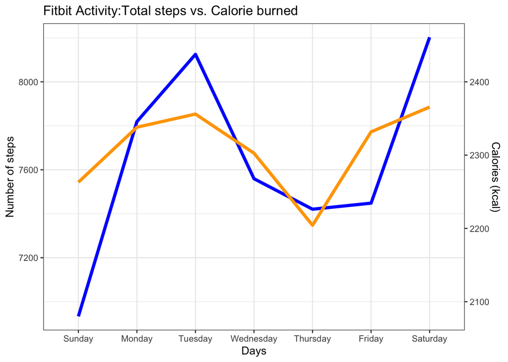

```r
# Trend between Total steps and calorie burned

ggplot(weekday_avg, aes(x=WeekDay)) +

  geom_line( aes(y=avg_steps), linewidth=1.5,group=1, color="blue") +
  geom_line( aes(y=avg_calories/0.3), linewidth=1.5,group=1, color="orange") +

  scale_y_continuous(

    # Features of the first axis
    name = "Number of steps",

    # Add a second axis and specify its features
    sec.axis = sec_axis(~.*0.3, name="Calories (kcal)")) +
  theme_bw()+ labs(title="Fitbit Activity:Total steps vs. Calorie burned",
  x="Days")
```

We also observe a consistent trend between Total Steps and Calories Burned, which is in line with the expected outcome that higher user activity leads to increased calorie expenditure.

Moving forward, we will categorize the activities based on their percentage of total distance into four groups: Active, Moderate, Light, and Barely Moving.

```r
# Add columns of activities percentage of total distance
jointdataset_check1<-jointdataset_check1 %>%
  mutate(TotalDistance_calc=(VeryActiveDistance+ModeratelyActiveDistance+LightActiveDistance+SedentaryActiveDistance),
        per_veryactive_distance=ifelse(VeryActiveDistance!=0,VeryActiveDistance/TotalDistance_calc,0),
        per_moderateactive_distance=ifelse(ModeratelyActiveDistance!=0,ModeratelyActiveDistance/TotalDistance_calc,0),
        per_lightactive_distance=ifelse(LightActiveDistance!=0,LightActiveDistance/TotalDistance_calc,0),
        per_sedentaryactive_distance=ifelse(SedentaryActiveDistance!=0,SedentaryActiveDistance/TotalDistance_calc,0))
```

```r
# Add a column: category to categorize the activity level into four group - Active, Moderate, Light, and Barely moving
jointdataset_check1<-jointdataset_check1 %>%
  mutate(category=case_when(
    per_veryactive_distance>=0.5 ~ "Active",
    per_moderateactive_distance>=0.5 ~ "Moderate",
    per_lightactive_distance>=0.5  ~ "Light",
    per_veryactive_distance+per_moderateactive_distance+per_lightactive_distance<=0.05  ~ "Barely moving",
    .default = "Light"))
```

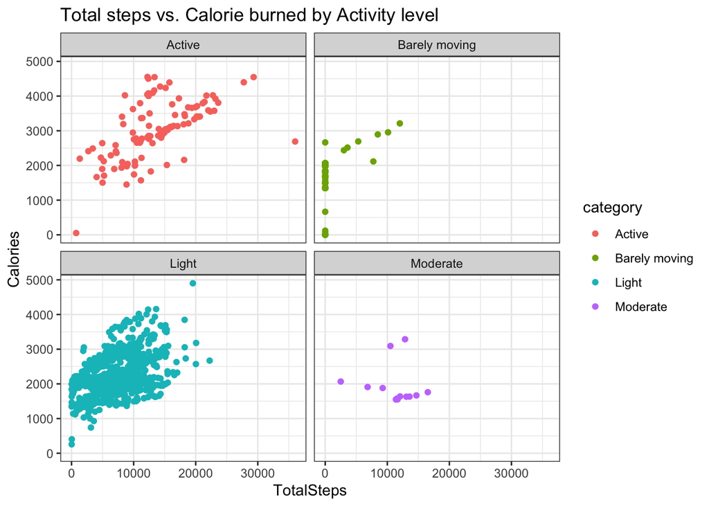

```r
ggplot(data=jointdataset_check1, aes(x=TotalSteps, y= Calories)) +
  geom_point(aes(color=category)) +
  facet_wrap(~category) + theme_bw()+ labs(title="Total steps vs. Calorie burned by Activity level",
  x="TotalSteps")
```

We observe a positive correlation between calories and total steps for the Active and Light activity levels. However, there is an anomaly where the record with the highest total steps does not correspond to the highest calories burned. In the Moderate category, the dataset is too limited to discern a clear trend. Regarding the Barely Moving category, we notice some unusual patterns: many records have zero total steps but show calories burned, or they display both total steps and calories burned but do not fit into the Active, Moderate, or Light Active distance categories.

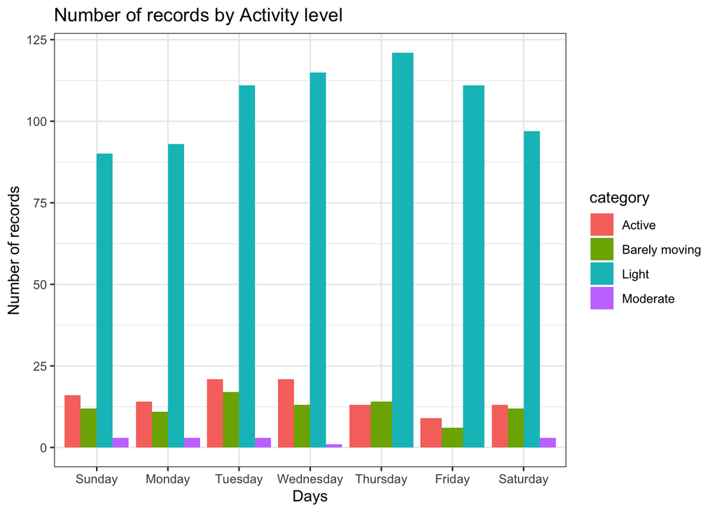

```r
ggplot(jointdataset_check1, aes(x = WeekDay, fill = category)) +
  geom_bar(position = 'dodge') + theme_bw()+ labs(title="Number of records by Activity level",
  x="Days", y="Number of records")
```

Most of users are doing Light activity.

```r
# Summary by category and average calorie burn
category_by_calories <- jointdataset_check1 %>%
  group_by(category) %>%
  summarise(avg_calories = mean(Calories)) %>%
  ungroup()
```

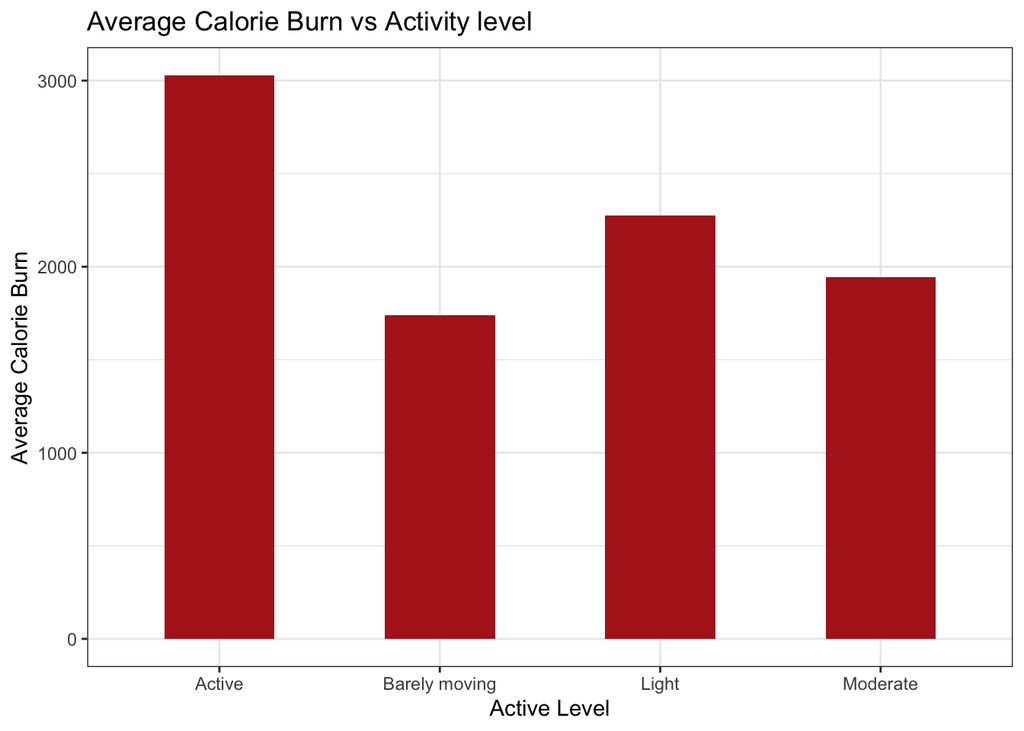

```r
ggplot(category_by_calories, aes(x = category, y = avg_calories)) +
  geom_bar(stat = 'identity', width = 0.5, fill = 'firebrick') + theme_bw()+ labs(title="Average Calorie Burn vs Activity level",
  x="Active Level", y="Average Calorie Burn")
```

The Active category exhibits a higher calorie burn, while the Barely Moving category displays lower calorie expenditure.

I plan to investigate the “Barely Moving” category more closely because of some peculiar records—specifically, those with zero total steps and distance but showing calorie burn. Based on the summary below, it’s likely that the smart device assigned these records to the Sedentary activity category.

```r
# Filter category : Barely moving
barely_move_details <-jointdataset_check1 %>%
  filter(category=='Barely moving')
# group by Id and show summary for some columns
barely_move_details %>%
  group_by(ActivityDate) %>%
  dplyr::select(ActivityDate,TotalSteps,Calories,SedentaryActiveDistance,SedentaryMinutes)
```

```
## # A tibble: 85 × 5
## # Groups:   ActivityDate [30]
##    ActivityDate TotalSteps Calories SedentaryActiveDistance SedentaryMinutes
##    <date>            <dbl>    <dbl>                   <dbl>            <dbl>
##  1 2016-05-12            0        0                       0             1440
##  2 2016-04-24            0     1347                       0             1440
##  3 2016-04-25            0     1347                       0             1440
##  4 2016-04-26            0     1347                       0             1440
##  5 2016-04-27            4     1348                       0             1439
##  6 2016-05-02            0     1348                       0             1440
##  7 2016-05-07            0     1347                       0             1440
##  8 2016-05-08            0     1347                       0             1440
##  9 2016-05-09            0     1347                       0             1440
## 10 2016-05-10            0     1347                       0             1440
## # ℹ 75 more rows
```

Now, let’s focus on Sedentary activity. Typically, walking less than 5,000 steps a day is categorized as sedentary. However, our analysis has revealed that some records with over 5,000 steps per day are still classified as Sedentary activity. Hence, it may be necessary for the company to reconsider and redefine Sedentary Activity on the device. Additional insights on Sedentary Activity can be found below. We can find more information regarding Sedentary Activity as following [UTSouthewstern Medical Center](https://utswmed.org/medblog/how-many-steps-per-day/#:~:text=Walking%20less%20than%205%2C000%20steps%20each%20day%20is%20considered%20sedentary) and [CNN Health](https://edition.cnn.com/2023/08/08/health/steps-live-longer-wellness/index.html)

```r
barely_move_details %>%
  filter(TotalSteps>5000) %>%
  group_by(ActivityDate) %>%
  dplyr::select(ActivityDate,TotalSteps,Calories,SedentaryActiveDistance,SedentaryMinutes)
```

```
## # A tibble: 5 × 5
## # Groups:   ActivityDate [4]
##   ActivityDate TotalSteps Calories SedentaryActiveDistance SedentaryMinutes
##   <date>            <dbl>    <dbl>                   <dbl>            <dbl>
## 1 2016-04-12         7753     2115                       0             1440
## 2 2016-04-12        10122     2955                       0             1440
## 3 2016-04-16         5319     2693                       0             1440
## 4 2016-05-02         8469     2894                       0             1440
## 5 2016-05-03        12015     3212                       0             1440
```